Vamsi Gudipati

Portfolio · Sequence models · October 2026

# Forecasting a turbulence signal: recurrent networks, a Transformer, and the linear model that beats them

One velocity signal from a channel-flow simulation, extracted byte for byte from 106 files, cut into windows of 300 past values and the next 10. Recurrent networks halve the error of persistence and a small Transformer ties it, with three seeds deciding both verdicts. On exactly the same windows, a linear autoregressive model fitted in 42 milliseconds is 77 to 258 times better than every network, because ten steps of this signal are almost a straight line. Pushing the horizon to 300 steps narrows that lead to 7 per cent without reversing it, and retraining the Transformer at a usable learning rate makes it beat persistence, but not the GRU.

**Vamsi Gudipati** Time-series forecasting · RNN, GRU, LSTM · Transformers · Baselines · Horizon [Repository](https://github.com/vamsigudipati/cfd-signal-forecasting-rnn-transformer)

5.64 GB → 0.95 MB

106 simulation files to one signal, reproduced byte for byte

0.0525 ± 0.0006

GRU test error over 10 steps, against persistence 0.1028 (3 seeds)

0.000399

linear autoregressive model, one least-squares solve in 42 ms, 77 to 258 × better than every network

73 × → 1.07 ×

the linear lead over the GRU from 10 to 300 steps: narrower, never reversed

0.104 → 0.064

the Transformer retrained at 1e-3 with early stopping: beats persistence, trails the GRU

## Objective

A probe in a simulation, a pressure tap on a wing or a sensor in a plant gives one signal in time, and forecasting a few steps ahead is the first thing a controller or a monitor needs. Recurrent networks and Transformers are the standard answer for sequences. I wanted to see what they actually buy on a real turbulence signal, the streamwise velocity at one height in a direct numerical simulation of channel flow, and to measure them against references that cost nothing to build. The work is five stages, each a notebook:

1. **Stage 1 — Extracting one near-wall velocity signal from 106 simulation files.** A reusable loader reads 106 simulation files (5.64 GB), keeps one column of the velocity profile, and writes a 0.95 MB signal file that records which file every sample came from, so no training window straddles two files.
2. **Stage 2 — Forecasting the signal with recurrent networks.** Windows of 300 past values and the next 10, split in time, scaled from training only; a dense network, SimpleRNN, GRU and LSTM against persistence (the last value repeated).
3. **Stage 3 — Forecasting the signal with a small Transformer.** The same task for a two-block Transformer encoder that predicts all ten values, with sweeps of its size, horizon and input length, and recurrent networks with a ten-value head as references.
4. **Stage 4 — Horizon and baselines: what the networks buy over a linear model.** Every network on exactly the same windows and test period, each predicting all ten steps, against persistence and a linear autoregressive model fitted by least squares, with the error at every future step.
5. **Stage 5 — Longer horizons, and the Transformer with a training budget it can use.** The two questions Stage 4 left open: horizons of 10, 30, 100 and 300 steps on one window set, to find where the linear model stops winning, and the Transformer retrained at the recurrent networks' learning rate with early stopping instead of a 50-epoch cap.

Every training is repeated with seeds 0, 1 and 2, seed 0 being the base run, and I report the mean, the standard deviation and the range. A difference smaller than that spread is not an effect, and on this signal that rule changes more than one verdict.

## Problem statement

Given the last 300 samples of the velocity at one wall-normal position (3 time units at a sampling step of 0.01), predict the next 10. Is a learned sequence model better than doing nothing clever? Which architecture, and does a difference survive a change of seed? And the question an engineer should ask before training anything: how far does a linear extrapolation of the past get on the same windows?

[figure not shown]

**The path through Stages 1 to 4.** One signal file written once, 7,419 windows split in time with one scaling, two references that need no training, four networks trained with three seeds, and every model scored step by step on the same 1,114 test windows. A network earns its place only if it beats the references by more than its spread.

[figure not shown]

**How the stages connect.** Stage 1 trains nothing and writes the signal file and its loader; Stages 2 and 3 read the same file with the same windows and persistence as their reference; Stage 4 adds the linear model, gives every network a ten-value head and reuses Stage 3's Transformer code unchanged.

[figure not shown]

**What is held out.** The 7,419 windows in time order, 70 per file (69 in the last). Training takes the first 70 %, validation and test the next two 15 % blocks; the cuts fall inside files 30075 and 30091. The mean and standard deviation are fitted on training inputs only.

## Method

### One signal, cut so that nothing leaks

[figure not shown]

**From 106 files to 7,419 windows.** Each file holds 1,000 time steps of a 201-point velocity profile; column 50 is kept, giving one signal of 106,000 samples with a file index per sample. Windows of 300 inputs and 10 targets, stride 10, never cross a file join; the split is in time, and only the training windows are shuffled.

The loader is a class rather than a script, so that the signal is extracted once and the three later stages read the same file with the same windowing code. Two details of the split matter for honesty. The windows overlap (length 310, stride 10), so the first 30 windows after each cut reuse input samples from the block before it; no target is ever shared. And the scaling statistics (mean 0.9274, standard deviation 0.1015) come from the training inputs alone.

### Two references that need no training

Persistence repeats the last observed value for all ten steps. The linear autoregressive model is one matrix: the 300 inputs and a constant, mapped to the 10 targets by least squares on the training windows, 3,010 coefficients solved in 42 ms. I also fit it on only the last L values, to see how much history a linear forecast needs.

### The networks

[figure not shown]

**Stage 2's four models.** A dense network on the flattened window, and SimpleRNN, GRU and LSTM with 32 units; each ends in `Dense(1)`, so one value is compared with all ten targets.

[figure not shown]

**Stage 3's Transformer.** A per-step embedding to 32 channels plus a learned positional table, two encoder blocks with four heads, the last step and the average over 300 steps concatenated, and a ten-value head: 31,562 weights.

Stage 2 trains with Adam at 1e-3 on the mean absolute error, early stopping after 8 epochs without improvement. Stage 3 trains with Adam at 1e-4 on the squared error, gradient clipping at norm 1, the rate halved after 4 flat epochs and at most 50 epochs. In Stage 4 every recurrent network gets a ten-value head and each family keeps its own stage's learning rate, so the comparison is of models as they were set up, not of a tuned optimum.

### Which device

[figure not shown]

**One training step of each network inside `model.fit`, CPU against the Apple GPU** (batch 64, window 300, median of 30 steps after 10 warm-up steps, log scale). The dense network and SimpleRNN are far faster on the CPU; the gated networks and the Transformer are faster on the GPU.

Each network is placed on its faster device with `tf.device`, rather than one device for a whole stage. One caution came out afterwards: for the same weights, the Apple GPU's GRU kernel gives a different output from Keras's reference GRU (my Stage 2 GRU scores 0.0530 with the GPU and 0.469 with it hidden, while the LSTM gives 0.0536 on both). The GRU results here therefore reproduce only on an Apple GPU, and the GRU timing compares two different computations.

## Implementation

What was run, and with what.

| Item | Choice |
| --- | --- |
| Environment | Python 3.12, TensorFlow 2.18.1, Keras 3.6, tensorflow-metal 1.2; Apple M3 Max, 48 GB |
| Data | 106 HDF5 files `P125_83pi_30001` to `30106`, 1,000 steps each; streamwise velocity at y index 50 of 201; processed file 951,874 bytes |
| Windows | 300 inputs → 10 targets, stride 10, inside one file; 5,193 / 1,112 / 1,114 train, validation, test, in time; batch 64 |
| Stage 2 | Dense 64-64 ReLU; SimpleRNN, GRU, LSTM with 32 units; `Dense(1)` head; Adam 1e-3, MAE loss, up to 100 epochs, patience 8; sweeps of horizon (1, 10, 50), window (20, 80), size (8, 64) and two stacked G… |
| Stage 3 | d_model 32, 4 heads, feed-forward 64, 2 blocks, dropout 0.1; Adam 1e-4, clipnorm 1, MSE loss, at most 50 epochs; sweeps of size, output length (1, 5, 20), input length (100, 600), a residual target, a… |
| Stage 4 | Persistence; linear autoregressive model by least squares, also on the last L = 1 to 300 values; SimpleRNN, GRU, LSTM with a `Dense(10)` head and the Stage 3 Transformer, MSE loss, early stopping |
| Stage 5 | Windows of 300 past and 300 future values (4,345; 3,041 / 651 / 653 in time), Stage 2–4 scaling; horizons 10, 30, 100, 300 as the first h future values; GRU(32) with a `Dense(h)` head per horizon; Tra… |
| Seeds | 0, 1, 2 for every training, every training under 15 minutes; seed 0 is the base run |
| Run time | Stage 1 6 s, Stage 2 32 min, Stage 3 75 min, Stage 4 21 min, Stage 5 25 min, one at a time; the longest single training 244 s |

## Results 1 — The signal, exactly (Stage 1)

Running the extraction from the 106 raw files gave a file **byte-identical** to the one the later stages had been reading (SHA-1 `f0a7789…`): the stored signal equals the raw column to the last bit, and the 106 TFRecord shards it also writes read back identical.

Reading the files closely turned up three things worth knowing before training anything: the stored time vector restarts at 0 at the eighth file although the signal joins smoothly; the window loop yields 69 windows from the last file instead of 70; and the input overlap at the split cuts described above.

[figure not shown]

**What the processed file holds.** The signal, its time, the file index and the sample index of every value, a table of the 106 source files, the wall-normal grid and nine attributes that say where the data came from.

## Results 2 — Recurrent networks halve persistence (Stage 2)

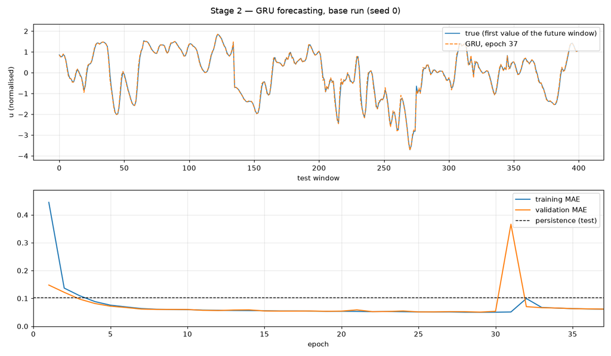

**The base-run GRU on the test windows** (first value of each future window) and its training curves. The validation error spikes at epoch 31 and recovers; early stopping restores the weights of the best epoch.

[figure not shown]

**Test error over the ten-step window, three seeds.** All three recurrent networks halve persistence; the dense network barely improves on it. The two linear marks are from Stage 4.

Mean absolute error in normalised units over the 10 future steps.

| Model | Test MAE, 3 seeds |
| --- | --- |
| Persistence | 0.1028 |
| Dense baseline | 0.0964 ± 0.0026 |
| SimpleRNN | 0.0578 ± 0.0038 |
| GRU | 0.0525 ± 0.0006 |
| LSTM | 0.0548 ± 0.0022 |
| Two stacked GRUs | 0.0307 ± 0.0078 |

The GRU is lower than the LSTM in all three seeds, but by less than the LSTM's own spread, so I do not call it better. Two stacked GRUs reach 0.031, but they vary far more between seeds (0.024 to 0.039).

The dense network, on a flattened window with about 23,500 weights, gains almost nothing over persistence: the recurrent layers' state is what carries the trend.

[figure not shown]

**Error at each future step** (log scale). Persistence grows linearly with the step; a linear extrapolation from two points is far below it at step 1; the linear model on 300 values is lower still at every step. The one-output networks predict a constant over the window, so their error is lowest near the middle and grows towards both ends.

The horizon sweep says the same in other words: a GRU trained for one step ahead reaches 0.0017 ± 0.0002, for 10 steps 0.0756 ± 0.0090 and for 50 steps 0.5912 ± 0.0059. In the sweeps, each capped at 40 epochs and scored at step 10, the window length is not monotonic (20 inputs 0.0694, 80 inputs 0.0528, 300 inputs 0.0756) and 8 units are too few (0.0860, against 0.0537 with 64).

## Results 3 — The Transformer ties persistence (Stage 3)

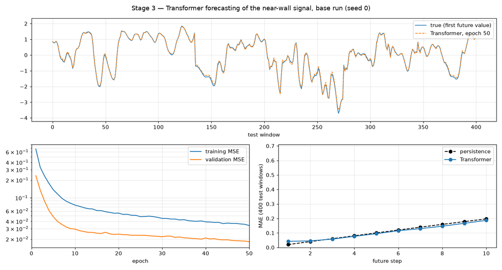

**The base-run Transformer**: forecasts on the test windows, training and validation loss over 50 epochs, and the error at each future step against persistence.

In the base run the Transformer scores 0.0969 against persistence's 0.1028, and the notebook's verdict line says it wins; in my earlier run of the same notebook it scored 0.1045 and the verdict said persistence. Over three seeds it is 0.1017 ± 0.0047, so neither verdict is an effect.

[figure not shown]

**Transformer minus persistence, step by step.** Above zero is worse. The Transformer is worse at steps 1 and 2 by more than its spread, and below persistence in the mean from step 4, by more than the standard deviation only at step 9.

[figure not shown]

**Still improving at the end.** The validation loss is lowest at the last of the 50 epochs in every seed: at a learning rate of 1e-4 the model is undertrained, not saturated.

[figure not shown]

**The Transformer against recurrent networks with a ten-value head** trained in the same stage. The recurrent references reach about 0.036; a residual target (predict the change from the last value) changes nothing for the Transformer.

The recurrent networks of the same stage reach 0.0363 to 0.0381, a third of the Transformer's error. That comparison mixes architecture with training settings (they train at 1e-3, the Transformer at 1e-4 for at most 50 epochs), so it says the Transformer as configured is the weak link, not that attention cannot forecast this signal. Its sweeps agree: a smaller model is worse (0.1164), a larger one no better (0.1025), and a shorter output is easier (one value 0.0312, twenty values 0.1941).

## Results 4 — A linear model beats every network (Stage 4)

[figure not shown]

**Left: error at each future step on the same 1,114 test windows**, networks as the mean of three seeds with their range. **Right: the linear model fitted on only the last L values.** Two past values (0.035) already match the recurrent networks and beat the Transformer; ten values (0.0013) beat every network by more than twenty times.

Test MAE at forecast steps 1, 5 and 10; networks are the mean of three seeds.

| Step | Persistence | Linear AR | SimpleRNN | GRU | LSTM | Transformer |
| --- | --- | --- | --- | --- | --- | --- |
| 1 | 0.0190 | 0.0000029 | 0.0061 | 0.0076 | 0.0146 | 0.0340 |
| 5 | 0.0943 | 0.000114 | 0.0192 | 0.0211 | 0.0269 | 0.0924 |
| 10 | 0.1844 | 0.00156 | 0.0731 | 0.0725 | 0.0777 | 0.1794 |

[figure not shown]

**What the extra complexity buys** (log scales). Error over the ten-step window against the number of trained weights or fitted coefficients; dots are seeds.

Mean over three seeds for the networks; every model sees the same windows, split and scaling.

| Model | Weights | Training time | Test MAE | Error ÷ linear |
| --- | --- | --- | --- | --- |
| Linear autoregressive | 3,010 coefficients | 42 ms | 0.000399 | 1 |
| SimpleRNN (CPU) | 1,418 | 42 s | 0.0306 ± 0.0026 | 77 |
| GRU (GPU) | 3,690 | 83 s | 0.0307 ± 0.0017 | 77 |
| LSTM (GPU) | 4,682 | 68 s | 0.0354 ± 0.0102 | 89 |
| Transformer (GPU) | 31,562 | 216 s | 0.1031 ± 0.0028 | 258 |
| Persistence | 0 | — | 0.1028 | 257 |

Every network is 77 to 258 times worse than one least-squares solve. With ten outputs the recurrent networks improve on their one-output versions (about 0.031 against 0.053) and still do not come close. The reason is the signal, not the networks: sampled every 0.01 time units, the near-wall velocity is smooth over ten samples, so a linear extrapolation is nearly exact, and the linear model needs only about ten past values to get within about a factor of three of its best.

Among the networks, SimpleRNN, GRU and LSTM do not differ by more than their spreads, and the Transformer at its stage's settings does not beat persistence. GPU training was repeatable for a given seed: the Transformer's seeds 1 and 2 in this stage reproduce Stage 3's runs to seven digits, which also means those two are not independent repeats of Stage 3.

## Results 5 — Where the linear model stops winning, and a tuned Transformer (Stage 5)

Stage 4 left two questions open, and this stage answers both on one new window set: 300 past and 300 future values, 4,345 windows, split 3,041 / 651 / 653 in time with the earlier stages' scaling, so that horizons of 10, 30, 100 and 300 steps are scored on the same 653 test windows (a shorter horizon is simply the first h future values). The 300-step horizon, 3 time units, is the longest a 1,000-sample file allows.

[figure not shown]

**Error at each future step for four output windows** (log scale), on the same 653 test windows. A GRU with an h-value head is trained for each horizon, three seeds each; the linear model is refitted for each. The GRU beats persistence at every horizon and the linear model at none.

Test MAE over the whole output window, normalised units; the GRU is the mean of seeds 0, 1 and 2.

| Output window | Persistence | Linear AR | GRU, 3 seeds (range) | GRU ÷ linear |
| --- | --- | --- | --- | --- |
| 10 steps (0.1 time units) | 0.0941 | 0.00039 | 0.0289 (0.0268 – 0.0307) | 73 × |
| 30 steps (0.3) | 0.2411 | 0.0351 | 0.1673 (0.1643 – 0.1723) | 4.8 × |
| 100 steps (1) | 0.5522 | 0.3858 | 0.5013 (0.4990 – 0.5028) | 1.3 × |
| 300 steps (3) | 0.8712 | 0.6838 | 0.7306 (0.7303 – 0.7309) | 1.07 × |

The linear model's advantage shrinks from 73 times to 7 per cent as the horizon grows, but it never reverses: at every horizon the GRU's whole seed range lies above the linear error. At 300 steps both are approaching the error of predicting the mean (about 1 in these units), so the regime where the network might win, if it exists, lies beyond what a single file can test.

[figure not shown]

**The Transformer with a training budget it can use**, horizon 10 on the same 653 test windows. Left: the window error, bars the mean of three seeds and whiskers the range. Right: the error at each future step. At Stage 3's setting (Adam 1e-4, 50 epochs) the Transformer ties persistence as before; at 1e-3 with gradient clipping and early stopping it is well below persistence, and still twice the GRU's error.

The tuned Transformer: Adam 1e-3, clipnorm 1, patience 8, at most 100 epochs, the same 31,562 weights.

| Model, horizon 10 | Test MAE, 3 seeds (range) | Epochs | Against persistence |
| --- | --- | --- | --- |
| Persistence | 0.0941 | — | — |
| Linear autoregressive | 0.00039 | 48 ms fit | 243 × better |
| GRU (part a) | 0.0289 (0.0268 – 0.0307) | 73 – 81 | 3.3 × better |
| Transformer, Stage 3 setting | 0.1038 (0.1022 – 0.1062) | 50, 50, 50 | no effect |
| Transformer, tuned | 0.0644 (0.0555 – 0.0702) | 75, 52, 45 | 1.5 × better, beyond the seed range |

The tuned Transformer gains 0.030 over persistence, twice its seed range of 0.015, so this time the verdict holds. Its best seed (0.0555) is still above the GRU's worst (0.0307), and its spread between seeds is four times the GRU's. So Stage 3's result was a training budget, not a limit of attention; but on this signal at this horizon the small Transformer, even trained properly, does not reach a 32-unit GRU, and neither reaches one least-squares solve.

For orientation only, because the window sets differ: on Stage 4's 1,114 windows persistence was 0.1028, the linear model 0.00040, the GRU 0.0307 and the Transformer at its stage's setting 0.1031; the same ranking and the same conclusions appear on the new set.

## Key observations

1. **Measure the reference that costs nothing first.** On this signal a linear model fitted in 42 ms is 77 times better than the best network; persistence alone, the usual baseline, would have made the networks look good.
2. **Smooth at the sampling rate means linear at short horizons, and the lead lasts.** Ten samples of a near-wall velocity at Δt = 0.01 are close to a straight line. Out to 300 steps (3 time units) the linear model's lead over the GRU shrinks from 73 times to 7 per cent, but at no horizon a single file can hold does the GRU overtake it.
3. **Three seeds overturn single-run verdicts.** The Transformer's "best method" flips between runs of the same notebook; over three seeds it ties persistence. The GRU-over-LSTM ordering holds in every seed but is smaller than the spread.
4. **The output head is part of the model.** One output for ten targets predicts a constant; giving the same recurrent networks ten outputs, with Stage 4's training setup, drops their error from about 0.053 to 0.031.
5. **A comparison of architectures is also a comparison of settings.** The Transformer trained at 1e-4 for 50 epochs is still improving when it stops; retrained at 1e-3 with clipping and early stopping, the same model drops from 0.104 to 0.064 and beats persistence beyond its seed range, yet still trails the GRU by two times.
6. **The fast device is not always the same computation.** The Apple GPU's GRU kernel gives different outputs from the reference GRU for the same weights; a timing table without that check would have compared two different models.

## Conclusion

The data path is exact: 5.64 GB of simulation output becomes a 0.95 MB signal, byte for byte reproducible, with every window inside one file and the scaling fitted on training data only. On that signal recurrent networks halve persistence and a small Transformer ties it, but a linear autoregressive model on the same windows beats all of them by two orders of magnitude, because ten steps of this signal are almost linear.

Stage 5 tested the two objections to that verdict. Extending the horizon to 300 steps, 3 time units, narrows the linear model's lead over the GRU from 73 times to 7 per cent but never closes it. Giving the Transformer the recurrent networks' learning rate and early stopping turns its tie with persistence into a clear win, from 0.104 to 0.064, so Stage 3's result was a training budget rather than a limit of the architecture; even so it remains twice the GRU's error and far from the linear model.

What the stages do not establish: a horizon beyond one file's length, where the signal joins smoothly but the stored time does not, so the regime where a network might overtake the linear model is still untested; only one architecture size was tuned; one wall-normal position of one simulation was used; and the GRU results are tied to the Apple GPU. The next steps are windows across file joins for horizons beyond 3 time units, the GRU retrained on the CPU, and a forecast of a quantity that is less smooth at its sampling rate, such as the wall shear stress.

## Code, data and reproducibility

The five notebooks of the repository, each also exported as HTML with all outputs.

| Notebook | Stage |
| --- | --- |
| `01_extract_cfd_signal.ipynb` with `cfd_data_tools.py` | Stage 1 — Extracting one near-wall velocity signal from 106 simulation files |
| `02_recurrent_forecasting.ipynb` | Stage 2 — Forecasting the signal with recurrent networks |
| `03_transformer_forecasting.ipynb` | Stage 3 — Forecasting the signal with a small Transformer |
| `04_horizon_and_baselines.ipynb` | Stage 4 — Horizon and baselines: what the networks buy over a linear model |
| `05_horizon_and_tuned_transformer.ipynb` | Stage 5 — Longer horizons, and the Transformer with a training budget it can use |

| Item | Where |
| --- | --- |
| Repository | vamsigudipati/cfd-signal-forecasting-rnn-transformer: the five executed notebooks, the loader, the processed signal, result tables and figures for every experiment and seed, every model my runs traine… |
| Data | `data/utmp_y50_raw_timeseries.h5` (0.95 MB, in git) is all that Stages 2 to 5 need. The 106 raw simulation files that Stage 1 reads (5.64 GB) are not distributed; Stage 1 is included to show how the s… |
| Environment | `requirements.txt` in the repository (Python 3.12, TensorFlow 2.18.1, Keras 3.6, tensorflow-metal 1.2) |
| Run | Stages 2 to 5 take about two and a half hours on a laptop, one at a time; the GRU numbers reproduce only on an Apple GPU |

The signal comes from a direct numerical simulation of turbulent channel flow; for the scientific context of forecasting such signals, see Cremades et al., *Nature Communications*, 2024.